# Tarea 1

Solís Díaz María del Carmen

Lunes 8 de Marzo de 2021)

Naturaleza.-Planta monopódica que mide 12 a 25 m de alto. Su tallo esbelto y estipitoso crece más o menos torcido; a menudo es más ancho en la base, donde puede tener alrededor de 80 cm de diámetro; la porción superior del tronco raramente alcanza los 30 cm. Sus hojas se agrupan en el ápice formando un penacho. Los pecíolos de 90 a 150 cm de largo se disponen en forma envolvente dando la estructura brosa al tallo. Es una planta monoica que tiene ores masculinas y femeninas reunidas en una in orescencia que se observa envuelta por una bráctea o espádice.

Valor de uso.-El trasplante deberá efectuarse con plántulas embolsadas que presenten la primera hoja palmeada en foliolos. Tradicionalmente se realiza en septiembre, bajo condiciones de temporal. Las plantaciones pueden ser establecidas bajo una distribución a “marco real” o bien a “tresbolillo”; en cualquier caso la distancia entre plantas deberá ser de 10 m. La densidad de plantación distribuida bajo “marco real” es de 100 palmas de coco por hectárea y de “ tresbolillo”, 120 palmas por hectárea. (SIAP,2019)

Valor de cambio.- México es el séptimo productor de coco en el mundo y segundo de América, después de India, Indonesia, Filipinas, Sri Lanka y Papúa Nueva Guinea, quienes concentran 91 por ciento de la superficie plantada; seguido por Brasil con el 2.4 por ciento y México con una participación de 1.4 por ciento de la producción, según Tetra Pak. Acapulcoco domina el mercado con una participación de 41.2 por ciento en las ventas de la bebida del fruto del cocotero, seguido por A de Coco con 19.5 y Coco Niau con el 17 por ciento, reveló Euromonitor. (Financiero,2017) Valor.-Ocupamos el 8° lugar como productor mundial (con 232,729 toneladas en 2017). También en el año 2012 ocupamos esa posición.

México aporta el 2% a la producción total del cultivo en el mundo. Las exportaciones de copra y aceite se han incrementado desde 2011. La demanda de aceite se ha incrementado en 10 países. En México el estado con mayor producción de este es Guerrero. Se utiliza prácticamente todo el fruto, se obtiene agua para beber y su pulpa para comer. El coco verde que en la costa le llaman media cuchara, se comercializa sobre las carreteras o en diversos puntos dentro de las poblaciones. El coco seco se comercializa destopado o pelado, es un poco más maduro que el coco verde, su carne ya es más gruesa, la cantidad de agua es menor, su apariencia externa es de un color café mas obscuro. Existen empresas que comercializan la pulpa fresca conservada al alto vacío.

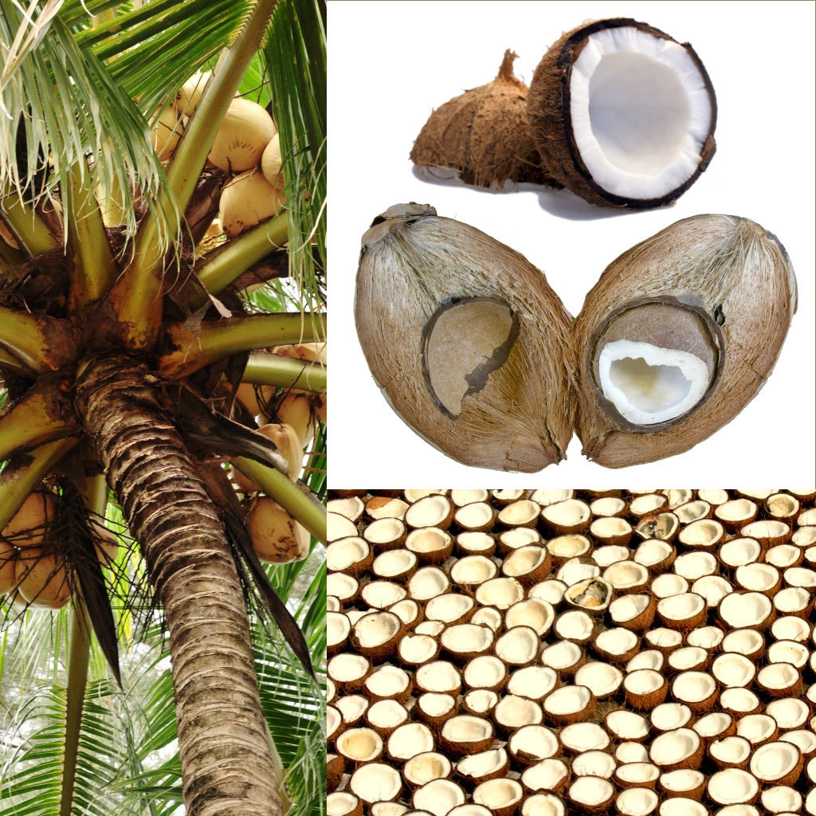

Fuente:Wikipedia

## Bibliografía

1. SIAP (2019) Monográfias de productos agroalimentarios mexicanos SIAP Recuperado el 8 de Marzo de 2021 de https://www.gob.mx/siap/documentos/monografias
2. El Financiero (2017)Así es como creció el negocio del Coco en México, El Financiero Recuperado el 8 de marzo de 2021 de https://www.elfinanciero.com.mx/empresas/asi-es-como-crecio-el-jugoso-negocio-del-coco-en-mexico#:~:text=de%20Tetra%20Pak.-,El%20valor%20del%20mercado%20del%20agua%20de%20coco%20en%20M%C3%A9xico,del%202016%2C%20seg%C3%BAn%20Euromonitor%20International.&text=A%20de%20Coco%2C%20de%20la,agua%20de%20coco%20en%202013.